# Nass TSA VDYP Tables

G Nienaber

October 24, 2019

# 1 Load VDYP Data in to PostGRES

Create a new table and read in CSV file from Wenli.

```sql
drop table if exists tsa43_vdyp;

create table tsa43_vdyp (
  feat_id int,
  age int,
  vol numeric
);

copy tsa43_vdyp
  from 'C:/Data/tsa43/vdyp/DKM_NaturalStand_YT_V2.CSV'
  csv header;
```

|  | feat_id | age | vol |
| --- | --- | --- | --- |
| 1 | 3500292 | 10 | 0.00 |
| 2 | 3500292 | 20 | 0.00 |
| 3 | 3500292 | 30 | 0.00 |
| 4 | 3500292 | 40 | 0.00 |
| 5 | 3500292 | 50 | 0.00 |
| 6 | 3500292 | 60 | 0.00 |
| 7 | 3500292 | 70 | 0.00 |
| 8 | 3500292 | 80 | 0.00 |
| 9 | 3500292 | 90 | 0.00 |
| 10 | 3500292 | 100 | 5.58 |

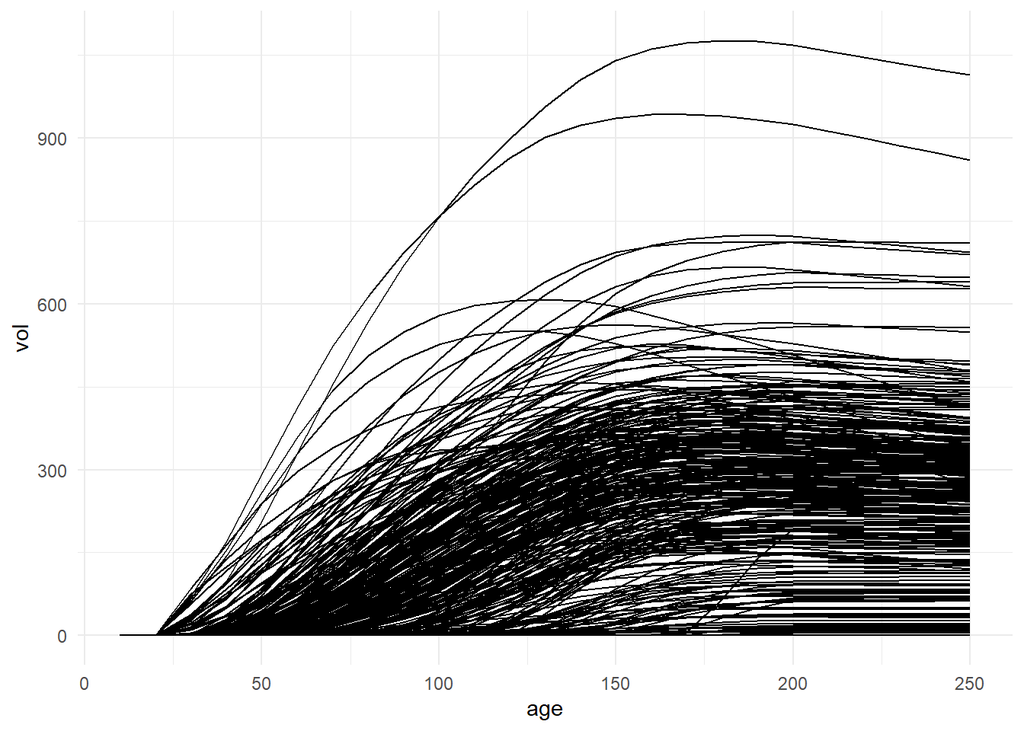

# 2 Add Mean Annual Increment

For use in calculating culmination MAI.

```sql
alter table tsa43_vdyp
  add column mai numeric default 0;

update tsa43_vdyp
  set mai = vol / age
  where vol > 0;
```

|  | feat_id | age | vol | mai |
| --- | --- | --- | --- | --- |
| 1 | 3500292 | 10 | 0.00 | 0.0000 |
| 2 | 3500292 | 30 | 0.00 | 0.0000 |
| 3 | 3500292 | 40 | 0.00 | 0.0000 |
| 4 | 3500292 | 20 | 0.00 | 0.0000 |
| 5 | 3500292 | 60 | 0.00 | 0.0000 |
| 6 | 3500292 | 70 | 0.00 | 0.0000 |
| 7 | 3500292 | 80 | 0.00 | 0.0000 |
| 8 | 3500292 | 90 | 0.00 | 0.0000 |
| 9 | 3500292 | 50 | 0.00 | 0.0000 |
| 10 | 3500292 | 100 | 5.58 | 0.0558 |

# 3 Create a Table for Yield Curve Statistics

A table with one row for each yield curve to contain all the curve-level statistics.

```sql
drop table if exists tsa43_vdyp_stats;

create table tsa43_vdyp_stats as (
  select feat_id from tsa43_vdyp
  group by 1 order by 1
);

alter table tsa43_vdyp_stats
  add column maxvol numeric default 0,
  add column age_maxvol int default 0,
  add column cmai numeric default 0,
  add column age_cmai int default 0,
  add column cmai95 numeric default 0,
  add column u_mai_age int default 0,
  add column u_mai numeric default 0,
  add column l_mai numeric default 0,
  add column age_cmai95 numeric default 0,
  add column vri_age numeric default 0,
  add column vri_vol numeric default 0,
  add column u_vol numeric default 0,
  add column l_vol numeric default 0,
  add column p_low numeric default 0,
  add column vdyp_vol numeric default 0;
```

|  | feat_id | maxvol | age_maxvol | cmai | age_cmai | cmai95 | u_mai_age | u_mai | l_mai | age_cmai95 | vri_age | vri_vol | u_vol | l_vol | p_low | vdyp_vol |
| --- | --- | --- | --- | --- | --- | --- | --- | --- | --- | --- | --- | --- | --- | --- | --- | --- |
| 1 | 3500292 | 0 | 0 | 0 | 0 | 0 | 0 | 0 | 0 | 0 | 0 | 0 | 0 | 0 | 0 | 0 |
| 2 | 3500293 | 0 | 0 | 0 | 0 | 0 | 0 | 0 | 0 | 0 | 0 | 0 | 0 | 0 | 0 | 0 |
| 3 | 3500294 | 0 | 0 | 0 | 0 | 0 | 0 | 0 | 0 | 0 | 0 | 0 | 0 | 0 | 0 | 0 |
| 4 | 3500295 | 0 | 0 | 0 | 0 | 0 | 0 | 0 | 0 | 0 | 0 | 0 | 0 | 0 | 0 | 0 |
| 5 | 3500296 | 0 | 0 | 0 | 0 | 0 | 0 | 0 | 0 | 0 | 0 | 0 | 0 | 0 | 0 | 0 |
| 6 | 3500297 | 0 | 0 | 0 | 0 | 0 | 0 | 0 | 0 | 0 | 0 | 0 | 0 | 0 | 0 | 0 |
| 7 | 3500298 | 0 | 0 | 0 | 0 | 0 | 0 | 0 | 0 | 0 | 0 | 0 | 0 | 0 | 0 | 0 |
| 8 | 3500299 | 0 | 0 | 0 | 0 | 0 | 0 | 0 | 0 | 0 | 0 | 0 | 0 | 0 | 0 | 0 |
| 9 | 3500300 | 0 | 0 | 0 | 0 | 0 | 0 | 0 | 0 | 0 | 0 | 0 | 0 | 0 | 0 | 0 |
| 10 | 3500301 | 0 | 0 | 0 | 0 | 0 | 0 | 0 | 0 | 0 | 0 | 0 | 0 | 0 | 0 | 0 |

# 4 Maximum Volume Achieved

Sub-query identifies the maximum volume associated with each curve.

```sql
update tsa43_vdyp_stats set
  maxvol = sub.maxvol
from (
    select feat_id, max(vol) maxvol from tsa43_vdyp group by 1
  ) as sub
where tsa43_vdyp_stats.feat_id = sub.feat_id;
```

|  | feat_id | maxvol | age_maxvol | cmai | age_cmai | cmai95 | u_mai_age | u_mai | l_mai | age_cmai95 | vri_age | vri_vol | u_vol | l_vol | p_low | vdyp_vol |
| --- | --- | --- | --- | --- | --- | --- | --- | --- | --- | --- | --- | --- | --- | --- | --- | --- |
| 1 | 3500292 | 190.9356 | 0 | 0 | 0 | 0 | 0 | 0 | 0 | 0 | 0 | 0 | 0 | 0 | 0 | 0 |
| 2 | 3500293 | 257.7901 | 0 | 0 | 0 | 0 | 0 | 0 | 0 | 0 | 0 | 0 | 0 | 0 | 0 | 0 |
| 3 | 3500294 | 334.7207 | 0 | 0 | 0 | 0 | 0 | 0 | 0 | 0 | 0 | 0 | 0 | 0 | 0 | 0 |
| 4 | 3500295 | 449.0068 | 0 | 0 | 0 | 0 | 0 | 0 | 0 | 0 | 0 | 0 | 0 | 0 | 0 | 0 |
| 5 | 3500296 | 211.8090 | 0 | 0 | 0 | 0 | 0 | 0 | 0 | 0 | 0 | 0 | 0 | 0 | 0 | 0 |
| 6 | 3500297 | 344.3742 | 0 | 0 | 0 | 0 | 0 | 0 | 0 | 0 | 0 | 0 | 0 | 0 | 0 | 0 |
| 7 | 3500298 | 309.7460 | 0 | 0 | 0 | 0 | 0 | 0 | 0 | 0 | 0 | 0 | 0 | 0 | 0 | 0 |
| 8 | 3500299 | 418.4551 | 0 | 0 | 0 | 0 | 0 | 0 | 0 | 0 | 0 | 0 | 0 | 0 | 0 | 0 |
| 9 | 3500300 | 234.5696 | 0 | 0 | 0 | 0 | 0 | 0 | 0 | 0 | 0 | 0 | 0 | 0 | 0 | 0 |
| 10 | 3500301 | 326.4307 | 0 | 0 | 0 | 0 | 0 | 0 | 0 | 0 | 0 | 0 | 0 | 0 | 0 | 0 |

## 4.1 Low Site Threshold

The THLB netdown for Low Site uses a cutoff of 277 m<sup>3</sup>/ha. Take a look at these curves.

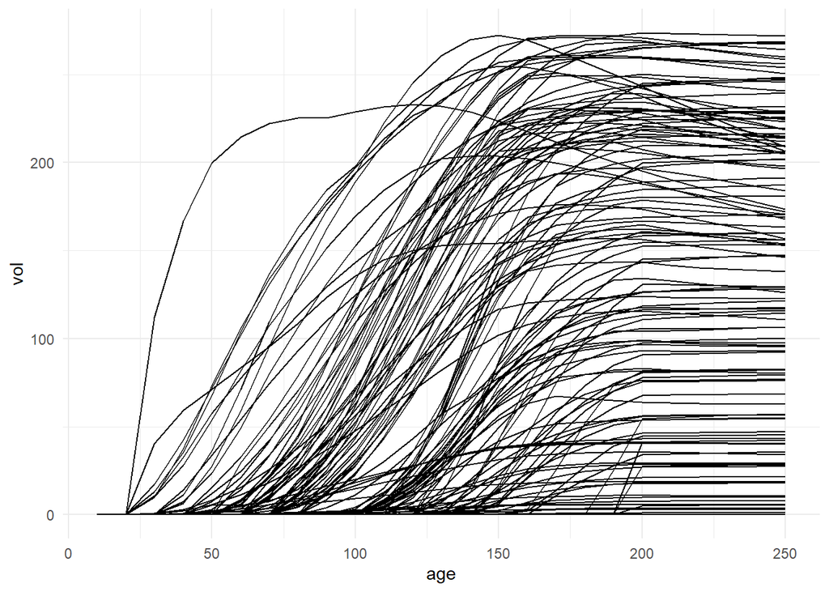

I’m not sure why I calculated the age at which the maximum volume is achieved. But here it is.

```sql
update tsa43_vdyp_stats set
  age_maxvol = tsa43_vdyp.age
from tsa43_vdyp
where tsa43_vdyp_stats.feat_id = tsa43_vdyp.feat_id and
  tsa43_vdyp_stats.maxvol = tsa43_vdyp.vol;
```

|  | feat_id | maxvol | age_maxvol | cmai | age_cmai | cmai95 | u_mai_age | u_mai | l_mai | age_cmai95 | vri_age | vri_vol | u_vol | l_vol | p_low | vdyp_vol |
| --- | --- | --- | --- | --- | --- | --- | --- | --- | --- | --- | --- | --- | --- | --- | --- | --- |
| 1 | 3500292 | 190.9356 | 250 | 0 | 0 | 0 | 0 | 0 | 0 | 0 | 0 | 0 | 0 | 0 | 0 | 0 |
| 2 | 3500293 | 257.7901 | 160 | 0 | 0 | 0 | 0 | 0 | 0 | 0 | 0 | 0 | 0 | 0 | 0 | 0 |
| 3 | 3500294 | 334.7207 | 180 | 0 | 0 | 0 | 0 | 0 | 0 | 0 | 0 | 0 | 0 | 0 | 0 | 0 |
| 4 | 3500295 | 449.0068 | 200 | 0 | 0 | 0 | 0 | 0 | 0 | 0 | 0 | 0 | 0 | 0 | 0 | 0 |
| 5 | 3500296 | 211.8090 | 180 | 0 | 0 | 0 | 0 | 0 | 0 | 0 | 0 | 0 | 0 | 0 | 0 | 0 |
| 6 | 3500297 | 344.3742 | 160 | 0 | 0 | 0 | 0 | 0 | 0 | 0 | 0 | 0 | 0 | 0 | 0 | 0 |
| 7 | 3500298 | 309.7460 | 180 | 0 | 0 | 0 | 0 | 0 | 0 | 0 | 0 | 0 | 0 | 0 | 0 | 0 |
| 8 | 3500299 | 418.4551 | 160 | 0 | 0 | 0 | 0 | 0 | 0 | 0 | 0 | 0 | 0 | 0 | 0 | 0 |
| 9 | 3500300 | 234.5696 | 180 | 0 | 0 | 0 | 0 | 0 | 0 | 0 | 0 | 0 | 0 | 0 | 0 | 0 |
| 10 | 3500301 | 326.4307 | 170 | 0 | 0 | 0 | 0 | 0 | 0 | 0 | 0 | 0 | 0 | 0 | 0 | 0 |

# 5 Culmination Mean Annual Increment

Use a sub-query to find the maximum MAI for each curve.

```sql
update tsa43_vdyp_stats set
  cmai = sub.cmai
from (
    select feat_id, max(mai) cmai from tsa43_vdyp group by 1
  ) as sub
where tsa43_vdyp_stats.feat_id = sub.feat_id;
```

|  | feat_id | maxvol | age_maxvol | cmai | age_cmai | cmai95 | u_mai_age | u_mai | l_mai | age_cmai95 | vri_age | vri_vol | u_vol | l_vol | p_low | vdyp_vol |
| --- | --- | --- | --- | --- | --- | --- | --- | --- | --- | --- | --- | --- | --- | --- | --- | --- |
| 1 | 3500292 | 190.9356 | 250 | 1.038324 | 0 | 0 | 0 | 0 | 0 | 0 | 0 | 0 | 0 | 0 | 0 | 0 |
| 2 | 3500293 | 257.7901 | 160 | 1.804149 | 0 | 0 | 0 | 0 | 0 | 0 | 0 | 0 | 0 | 0 | 0 | 0 |
| 3 | 3500294 | 334.7207 | 180 | 2.179858 | 0 | 0 | 0 | 0 | 0 | 0 | 0 | 0 | 0 | 0 | 0 | 0 |
| 4 | 3500295 | 449.0068 | 200 | 3.185446 | 0 | 0 | 0 | 0 | 0 | 0 | 0 | 0 | 0 | 0 | 0 | 0 |
| 5 | 3500296 | 211.8090 | 180 | 1.345679 | 0 | 0 | 0 | 0 | 0 | 0 | 0 | 0 | 0 | 0 | 0 | 0 |
| 6 | 3500297 | 344.3742 | 160 | 2.292728 | 0 | 0 | 0 | 0 | 0 | 0 | 0 | 0 | 0 | 0 | 0 | 0 |
| 7 | 3500298 | 309.7460 | 180 | 2.065493 | 0 | 0 | 0 | 0 | 0 | 0 | 0 | 0 | 0 | 0 | 0 | 0 |
| 8 | 3500299 | 418.4551 | 160 | 3.674917 | 0 | 0 | 0 | 0 | 0 | 0 | 0 | 0 | 0 | 0 | 0 | 0 |
| 9 | 3500300 | 234.5696 | 180 | 1.550497 | 0 | 0 | 0 | 0 | 0 | 0 | 0 | 0 | 0 | 0 | 0 | 0 |
| 10 | 3500301 | 326.4307 | 170 | 2.107546 | 0 | 0 | 0 | 0 | 0 | 0 | 0 | 0 | 0 | 0 | 0 | 0 |

Identify the culmination age. The actual peak is going to occur at an even decade because we don’t know the values between. An obvious statement but I wanted to remind myself.

```sql
update tsa43_vdyp_stats set
  age_cmai = tsa43_vdyp.age
from tsa43_vdyp
where tsa43_vdyp_stats.feat_id = tsa43_vdyp.feat_id and
  tsa43_vdyp_stats.cmai = tsa43_vdyp.mai;
```

|  | feat_id | maxvol | age_maxvol | cmai | age_cmai | cmai95 | u_mai_age | u_mai | l_mai | age_cmai95 | vri_age | vri_vol | u_vol | l_vol | p_low | vdyp_vol |
| --- | --- | --- | --- | --- | --- | --- | --- | --- | --- | --- | --- | --- | --- | --- | --- | --- |
| 1 | 3500292 | 190.9356 | 250 | 1.038324 | 170 | 0 | 0 | 0 | 0 | 0 | 0 | 0 | 0 | 0 | 0 | 0 |
| 2 | 3500293 | 257.7901 | 160 | 1.804149 | 130 | 0 | 0 | 0 | 0 | 0 | 0 | 0 | 0 | 0 | 0 | 0 |
| 3 | 3500294 | 334.7207 | 180 | 2.179858 | 140 | 0 | 0 | 0 | 0 | 0 | 0 | 0 | 0 | 0 | 0 | 0 |
| 4 | 3500295 | 449.0068 | 200 | 3.185446 | 120 | 0 | 0 | 0 | 0 | 0 | 0 | 0 | 0 | 0 | 0 | 0 |
| 5 | 3500296 | 211.8090 | 180 | 1.345679 | 150 | 0 | 0 | 0 | 0 | 0 | 0 | 0 | 0 | 0 | 0 | 0 |
| 6 | 3500297 | 344.3742 | 160 | 2.292728 | 130 | 0 | 0 | 0 | 0 | 0 | 0 | 0 | 0 | 0 | 0 | 0 |
| 7 | 3500298 | 309.7460 | 180 | 2.065493 | 120 | 0 | 0 | 0 | 0 | 0 | 0 | 0 | 0 | 0 | 0 | 0 |
| 8 | 3500299 | 418.4551 | 160 | 3.674917 | 90 | 0 | 0 | 0 | 0 | 0 | 0 | 0 | 0 | 0 | 0 | 0 |
| 9 | 3500300 | 234.5696 | 180 | 1.550497 | 140 | 0 | 0 | 0 | 0 | 0 | 0 | 0 | 0 | 0 | 0 | 0 |
| 10 | 3500301 | 326.4307 | 170 | 2.107546 | 140 | 0 | 0 | 0 | 0 | 0 | 0 | 0 | 0 | 0 | 0 | 0 |

# 6 95% of Culmination MAI

The age at which 95% of CMAI is achieved. This will be used to set minimum harvest ages.

First calculate 95% of CMAI and then find the first age at which this value is exceeded which is recorded as the upper MAI age.

```sql
update tsa43_vdyp_stats set
  cmai95 = cmai * 0.95;

update tsa43_vdyp_stats set
  u_mai_age = sub.age
from (
  select tsa43_vdyp.feat_id, min(age) age
  from tsa43_vdyp, tsa43_vdyp_stats
  where tsa43_vdyp_stats.feat_id = tsa43_vdyp.feat_id and
  tsa43_vdyp.mai >= tsa43_vdyp_stats.cmai95
  group by 1
) as sub
where tsa43_vdyp_stats.feat_id = sub.feat_id;
```

|  | feat_id | maxvol | age_maxvol | cmai | age_cmai | cmai95 | u_mai_age | u_mai | l_mai | age_cmai95 | vri_age | vri_vol | u_vol | l_vol | p_low | vdyp_vol |
| --- | --- | --- | --- | --- | --- | --- | --- | --- | --- | --- | --- | --- | --- | --- | --- | --- |
| 1 | 3500292 | 190.9356 | 250 | 1.038324 | 170 | 0.9864079 | 160 | 0 | 0 | 0 | 0 | 0 | 0 | 0 | 0 | 0 |
| 2 | 3500293 | 257.7901 | 160 | 1.804149 | 130 | 1.7139418 | 120 | 0 | 0 | 0 | 0 | 0 | 0 | 0 | 0 | 0 |
| 3 | 3500294 | 334.7207 | 180 | 2.179858 | 140 | 2.0708648 | 120 | 0 | 0 | 0 | 0 | 0 | 0 | 0 | 0 | 0 |
| 4 | 3500295 | 449.0068 | 200 | 3.185446 | 120 | 3.0261734 | 100 | 0 | 0 | 0 | 0 | 0 | 0 | 0 | 0 | 0 |
| 5 | 3500296 | 211.8090 | 180 | 1.345679 | 150 | 1.2783947 | 140 | 0 | 0 | 0 | 0 | 0 | 0 | 0 | 0 | 0 |
| 6 | 3500297 | 344.3742 | 160 | 2.292728 | 130 | 2.1780920 | 120 | 0 | 0 | 0 | 0 | 0 | 0 | 0 | 0 | 0 |
| 7 | 3500298 | 309.7460 | 180 | 2.065493 | 120 | 1.9622186 | 100 | 0 | 0 | 0 | 0 | 0 | 0 | 0 | 0 | 0 |
| 8 | 3500299 | 418.4551 | 160 | 3.674917 | 90 | 3.4911707 | 70 | 0 | 0 | 0 | 0 | 0 | 0 | 0 | 0 | 0 |
| 9 | 3500300 | 234.5696 | 180 | 1.550497 | 140 | 1.4729724 | 130 | 0 | 0 | 0 | 0 | 0 | 0 | 0 | 0 | 0 |
| 10 | 3500301 | 326.4307 | 170 | 2.107546 | 140 | 2.0021684 | 130 | 0 | 0 | 0 | 0 | 0 | 0 | 0 | 0 | 0 |

Next, select the MAI at the upper age and lower age. Then figure out the percent of the difference between the upper MAI and CMAI relative to the decadal difference. Since this is a percentage it can be turned into years of a decade by multiplying by 10 and then rounding.

```sql
update tsa43_vdyp_stats set
  u_mai = mai
from tsa43_vdyp
where tsa43_vdyp_stats.feat_id = tsa43_vdyp.feat_id and
  tsa43_vdyp.age = u_mai_age;

update tsa43_vdyp_stats set
  l_mai = mai
from tsa43_vdyp
where tsa43_vdyp_stats.feat_id = tsa43_vdyp.feat_id and
  tsa43_vdyp.age = u_mai_age-10;

update tsa43_vdyp_stats set
  age_cmai95 = u_mai_age - round((u_mai - cmai95) / (u_mai - l_mai) * 10)
where l_mai > 0;
```

|  | feat_id | cmai | age_cmai | cmai95 | u_mai_age | u_mai | l_mai | age_cmai95 |
| --- | --- | --- | --- | --- | --- | --- | --- | --- |
| 1 | 3500292 | 1.038324 | 170 | 0.9864079 | 160 | 1.002497 | 0.919664 | 158 |
| 2 | 3500293 | 1.804149 | 130 | 1.7139418 | 120 | 1.777697 | 1.705760 | 111 |
| 3 | 3500294 | 2.179858 | 140 | 2.0708648 | 120 | 2.078413 | 1.937346 | 119 |
| 4 | 3500295 | 3.185446 | 120 | 3.0261734 | 100 | 3.103119 | 2.936362 | 95 |
| 5 | 3500296 | 1.345679 | 150 | 1.2783947 | 140 | 1.318012 | 1.244091 | 135 |
| 6 | 3500297 | 2.292728 | 130 | 2.1780920 | 120 | 2.251099 | 2.144325 | 113 |
| 7 | 3500298 | 2.065493 | 120 | 1.9622186 | 100 | 1.971145 | 1.832563 | 99 |
| 8 | 3500299 | 3.674917 | 90 | 3.4911707 | 70 | 3.502017 | 3.046373 | 70 |
| 9 | 3500300 | 1.550497 | 140 | 1.4729724 | 130 | 1.509632 | 1.432319 | 125 |
| 10 | 3500301 | 2.107546 | 140 | 2.0021684 | 130 | 2.067117 | 1.974593 | 123 |

A large proportion of the THLB will be modelled on rotation ages between 120 years and 150 years.

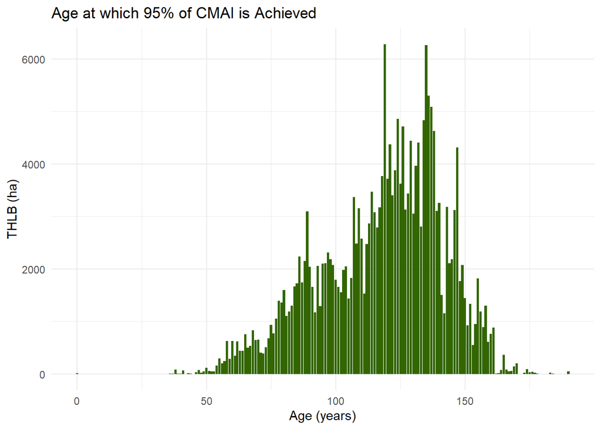

# 7 Compare Yield Table Volume to VRI Volume

Use the yield tables to calculate the current volume based on the current age. Requires interpolating between yield table entries.

```sql
--import age and volume from VRI for pine at 12.5
update tsa43_vdyp_stats set
  vri_age = proj_age_1,
  vri_vol = lvltot_125
from tsa43_res
where feat_id = feature_id and
  substr(spec_cd_1,1,1)='P';

--import age and volume from VRI for non-pine at 17.5
update tsa43_vdyp_stats set
  vri_age = proj_age_1,
  vri_vol = lvltot_175
from tsa43_res
where feat_id = feature_id and
  substr(spec_cd_1,1,1)!='P';

--set maximum age to be 250 for yield table lookup
update tsa43_vdyp_stats set
  vri_age = 250
where vri_age > 250;

--interpolate for ages between volume table entries
--calculate the percentage of the lower volume contribution
update tsa43_vdyp_stats set
  p_low = (ceil(vri_age/10.0)*10 - vri_age) / 10;

--import upper volume from the yield table
update tsa43_vdyp_stats set
  u_vol = vol
from tsa43_vdyp
where tsa43_vdyp_stats.feat_id = tsa43_vdyp.feat_id and
  tsa43_vdyp.age = ceil(vri_age/10.0)*10;

--import lower volume from the yield table
update tsa43_vdyp_stats set
  l_vol = vol
from tsa43_vdyp
where tsa43_vdyp_stats.feat_id = tsa43_vdyp.feat_id and
  tsa43_vdyp.age = floor(vri_age/10.0)*10;

--calculate volume
update tsa43_vdyp_stats set
  vdyp_vol = (p_low * l_vol) + ((1-p_low) * u_vol);
```

|  | feat_id | maxvol | age_maxvol | cmai | age_cmai | cmai95 | u_mai_age | u_mai | l_mai | age_cmai95 | vri_age | vri_vol | u_vol | l_vol | p_low | vdyp_vol |
| --- | --- | --- | --- | --- | --- | --- | --- | --- | --- | --- | --- | --- | --- | --- | --- | --- |
| 1 | 3500292 | 190.9356 | 250 | 1.038324 | 170 | 0.9864079 | 160 | 1.002497 | 0.919664 | 158 | 250 | 191.880 | 190.9356 | 190.9356 | 0.0 | 190.9356 |
| 2 | 3500293 | 257.7901 | 160 | 1.804149 | 130 | 1.7139418 | 120 | 1.777697 | 1.705760 | 111 | 206 | 251.868 | 251.2796 | 252.5823 | 0.4 | 251.8007 |
| 3 | 3500294 | 334.7207 | 180 | 2.179858 | 140 | 2.0708648 | 120 | 2.078413 | 1.937346 | 119 | 250 | 325.506 | 328.0294 | 328.0294 | 0.0 | 328.0294 |
| 4 | 3500295 | 449.0068 | 200 | 3.185446 | 120 | 3.0261734 | 100 | 3.103119 | 2.936362 | 95 | 96 | 293.450 | 310.3119 | 264.2726 | 0.4 | 291.8962 |
| 5 | 3500296 | 211.8090 | 180 | 1.345679 | 150 | 1.2783947 | 140 | 1.318012 | 1.244091 | 135 | 206 | 208.348 | 208.0649 | 208.9724 | 0.4 | 208.4279 |
| 6 | 3500297 | 344.3742 | 160 | 2.292728 | 130 | 2.1780920 | 120 | 2.251099 | 2.144325 | 113 | 250 | 326.211 | 331.6806 | 331.6806 | 0.0 | 331.6806 |
| 7 | 3500298 | 309.7460 | 180 | 2.065493 | 120 | 1.9622186 | 100 | 1.971145 | 1.832563 | 99 | 206 | 300.194 | 299.2947 | 301.8316 | 0.4 | 300.3095 |
| 8 | 3500299 | 418.4551 | 160 | 3.674917 | 90 | 3.4911707 | 70 | 3.502017 | 3.046373 | 70 | 206 | 400.397 | 398.7138 | 403.1810 | 0.4 | 400.5007 |
| 9 | 3500300 | 234.5696 | 180 | 1.550497 | 140 | 1.4729724 | 130 | 1.509632 | 1.432319 | 125 | 206 | 230.196 | 229.8767 | 230.8889 | 0.4 | 230.2816 |
| 10 | 3500301 | 326.4307 | 170 | 2.107546 | 140 | 2.0021684 | 130 | 2.067117 | 1.974593 | 123 | 250 | 309.129 | 316.0247 | 316.0247 | 0.0 | 316.0247 |

# 8 Check for missing yield curves

Make a left join between the resultant and the vdyp stats.

- The only VRI polygons with missing yield curves had no volume.
- Only five had ages greater than 30

```sql
select feature_id, feat_id, proj_age_1, lvltot_125
from tsa43_res
left join tsa43_vdyp_stats
on tsa43_res.feature_id = tsa43_vdyp_stats.feat_id
where feat_id is null and
  proj_age_1 > 30
group by 1,2,3,4 order by 1,2,3,4;
```

5 records

| feature_id | feat_id | proj_age_1 | lvltot_125 |
| --- | --- | --- | --- |
| 3708735 | NA | 31 | 0 |
| 5417753 | NA | 31 | 0 |
| 5437634 | NA | 46 | 0 |
| 8714772 | NA | 34 | 0 |
| 10872904 | NA | 46 | 0 |

Take a look at the opposite - see if there are any unecessary VDYP curves.

- There are over 1056 cuves that aren’t needed
- 161 have no volume

Probably the result of the rasterization process excluding very small polygons. These will be omitted when exporting the yield tables for SELES.

```sql
select feat_id, feature_id, maxvol, vri_age
from tsa43_vdyp_stats
left join tsa43_res
on tsa43_res.feature_id = tsa43_vdyp_stats.feat_id
where feature_id is null and maxvol > 0
limit 10;
```

10 records

| feat_id | feature_id | maxvol | vri_age |
| --- | --- | --- | --- |
| 3500336 | NA | 228.8643 | 0 |
| 3500343 | NA | 449.0068 | 0 |
| 3500346 | NA | 335.6567 | 0 |
| 3515228 | NA | 0.1694 | 0 |
| 3515266 | NA | 12.3275 | 0 |
| 3515357 | NA | 0.1505 | 0 |
| 3515941 | NA | 0.2961 | 0 |
| 3515946 | NA | 0.2611 | 0 |
| 5415406 | NA | 183.3667 | 0 |
| 5435024 | NA | 0.2165 | 0 |

# 9 Check for unusual curves

Take a look for unusual curves based on maximum volume.

- Found 265 curves with all zero volume

```sql
select * from tsa43_vdyp_stats
where maxvol = 0
and vri_age > 30;
```

102 records

| feat_id | maxvol | age_maxvol | cmai | age_cmai | cmai95 | u_mai_age | u_mai | l_mai | age_cmai95 | vri_age | vri_vol | u_vol | l_vol | p_low | vdyp_vol |
| --- | --- | --- | --- | --- | --- | --- | --- | --- | --- | --- | --- | --- | --- | --- | --- |
| 3703518 | 0 | 200 | 0 | 250 | 0 | 10 | 0 | 0 | 0 | 250 | NA | 0 | 0 | 0.0 | 0 |
| 3708294 | 0 | 200 | 0 | 220 | 0 | 10 | 0 | 0 | 0 | 250 | NA | 0 | 0 | 0.0 | 0 |
| 3708345 | 0 | 80 | 0 | 180 | 0 | 10 | 0 | 0 | 0 | 250 | NA | 0 | 0 | 0.0 | 0 |
| 3708445 | 0 | 160 | 0 | 130 | 0 | 10 | 0 | 0 | 0 | 250 | NA | 0 | 0 | 0.0 | 0 |
| 3712467 | 0 | 190 | 0 | 190 | 0 | 10 | 0 | 0 | 0 | 250 | NA | 0 | 0 | 0.0 | 0 |
| 3719311 | 0 | 90 | 0 | 30 | 0 | 10 | 0 | 0 | 0 | 250 | NA | 0 | 0 | 0.0 | 0 |
| 5419705 | 0 | 140 | 0 | 100 | 0 | 10 | 0 | 0 | 0 | 73 | NA | 0 | 0 | 0.7 | 0 |
| 5424506 | 0 | 150 | 0 | 30 | 0 | 10 | 0 | 0 | 0 | 63 | NA | 0 | 0 | 0.7 | 0 |
| 5424630 | 0 | 140 | 0 | 180 | 0 | 10 | 0 | 0 | 0 | 250 | NA | 0 | 0 | 0.0 | 0 |
| 5428288 | 0 | 70 | 0 | 100 | 0 | 10 | 0 | 0 | 0 | 63 | NA | 0 | 0 | 0.7 | 0 |
| 5428463 | 0 | 250 | 0 | 10 | 0 | 10 | 0 | 0 | 0 | 73 | NA | 0 | 0 | 0.7 | 0 |
| 5438755 | 0 | 20 | 0 | 60 | 0 | 10 | 0 | 0 | 0 | 208 | NA | 0 | 0 | 0.2 | 0 |
| 5447543 | 0 | 170 | 0 | 190 | 0 | 10 | 0 | 0 | 0 | 242 | NA | 0 | 0 | 0.8 | 0 |
| 5450101 | 0 | 180 | 0 | 210 | 0 | 10 | 0 | 0 | 0 | 242 | NA | 0 | 0 | 0.8 | 0 |
| 5452688 | 0 | 200 | 0 | 180 | 0 | 10 | 0 | 0 | 0 | 242 | NA | 0 | 0 | 0.8 | 0 |
| 5452807 | 0 | 20 | 0 | 30 | 0 | 10 | 0 | 0 | 0 | 242 | NA | 0 | 0 | 0.8 | 0 |
| 5452928 | 0 | 90 | 0 | 240 | 0 | 10 | 0 | 0 | 0 | 242 | NA | 0 | 0 | 0.8 | 0 |
| 5455890 | 0 | 160 | 0 | 130 | 0 | 10 | 0 | 0 | 0 | 242 | NA | 0 | 0 | 0.8 | 0 |
| 5486732 | 0 | 150 | 0 | 150 | 0 | 10 | 0 | 0 | 0 | 242 | NA | 0 | 0 | 0.8 | 0 |
| 3708179 | 0 | 200 | 0 | 200 | 0 | 10 | 0 | 0 | 0 | 250 | NA | 0 | 0 | 0.0 | 0 |
| 5430805 | 0 | 220 | 0 | 20 | 0 | 10 | 0 | 0 | 0 | 241 | NA | 0 | 0 | 0.9 | 0 |
| 5433744 | 0 | 90 | 0 | 100 | 0 | 10 | 0 | 0 | 0 | 55 | NA | 0 | 0 | 0.5 | 0 |
| 5437819 | 0 | 100 | 0 | 100 | 0 | 10 | 0 | 0 | 0 | 250 | NA | 0 | 0 | 0.0 | 0 |
| 5452962 | 0 | 230 | 0 | 140 | 0 | 10 | 0 | 0 | 0 | 242 | NA | 0 | 0 | 0.8 | 0 |
| 5461469 | 0 | 20 | 0 | 90 | 0 | 10 | 0 | 0 | 0 | 242 | NA | 0 | 0 | 0.8 | 0 |
| 5420007 | 0 | 130 | 0 | 80 | 0 | 10 | 0 | 0 | 0 | 63 | NA | 0 | 0 | 0.7 | 0 |
| 5424468 | 0 | 170 | 0 | 120 | 0 | 10 | 0 | 0 | 0 | 63 | NA | 0 | 0 | 0.7 | 0 |
| 5430806 | 0 | 10 | 0 | 120 | 0 | 10 | 0 | 0 | 0 | 241 | NA | 0 | 0 | 0.9 | 0 |
| 5433759 | 0 | 160 | 0 | 180 | 0 | 10 | 0 | 0 | 0 | 55 | NA | 0 | 0 | 0.5 | 0 |
| 5486804 | 0 | 250 | 0 | 120 | 0 | 10 | 0 | 0 | 0 | 242 | NA | 0 | 0 | 0.8 | 0 |

[output cut: 72 more lines]

Quality check for instances where vdyp_vol wasn’t produced

- Found only instances where the yield curve remained at zero late into the projection
- No instances where the VRI volume didn’t also show zero volume

```sql
select * from tsa43_vdyp_stats
where vdyp_vol = 0 and maxvol > 0 and vri_age > 30 and vri_vol > 0
limit 50;
```

[output not shown]

# 10 Residual Difference between VDYP Volume and VRI Volume

A residual graph gives an idea of how closely the modelled yields will match the VRI volumes.

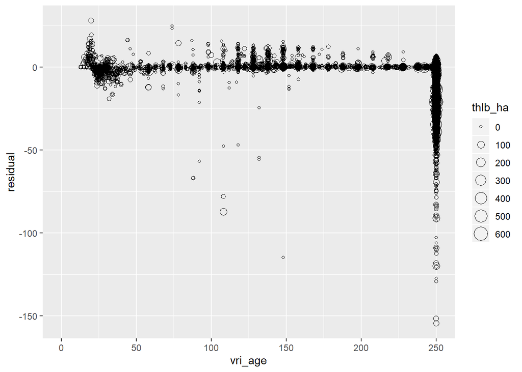

```r
dbGetQuery(db,'
  select feature_id, vri_age, (vri_vol - vdyp_vol) residual, sum(thlb_fact) thlb_ha
  from tsa43_vdyp_stats
  left join tsa43_netdown
  on tsa43_vdyp_stats.feat_id = tsa43_netdown.feature_id
  where vri_vol is not null
  group by 1,2,3 order by 1,2,3;
') %>%
ggplot(aes(vri_age, residual)) + geom_point(shape=1, aes(size=thlb_ha))
```

The largest residuals are at 250 years which is likely the result of using yield tables that end at 250 years. Volume in the VRI projection likely keep decreasing over time.

```sql
select *, (vri_vol - vdyp_vol) residual
from tsa43_vdyp_stats
where vri_vol is not null and (vri_vol - vdyp_vol) < -25 and vri_age > 50 and vri_age < 150;
```

14 records

| feat_id | maxvol | age_maxvol | cmai | age_cmai | cmai95 | u_mai_age | u_mai | l_mai | age_cmai95 | vri_age | vri_vol | u_vol | l_vol | p_low | vdyp_vol | residual |
| --- | --- | --- | --- | --- | --- | --- | --- | --- | --- | --- | --- | --- | --- | --- | --- | --- |
| 3708645 | 245.7296 | 250 | 1.419563 | 150 | 1.348585 | 120 | 1.357598 | 0.3116127 | 120 | 148 | 95.195 | 212.9345 | 197.8525 | 0.2 | 209.9181 | -114.72311 |
| 3708950 | 245.7296 | 250 | 1.419563 | 150 | 1.348585 | 120 | 1.357598 | 0.3116127 | 120 | 148 | 95.195 | 212.9345 | 197.8525 | 0.2 | 209.9181 | -114.72311 |
| 3725178 | 350.7988 | 200 | 2.230203 | 120 | 2.118693 | 80 | 2.154790 | 0.9320870 | 80 | 108 | 162.111 | 244.9919 | 221.3117 | 0.2 | 240.2559 | -78.14486 |
| 3725184 | 332.5801 | 200 | 2.057531 | 130 | 1.954654 | 80 | 2.016423 | 0.7502300 | 80 | 108 | 134.190 | 225.6148 | 204.1270 | 0.2 | 221.3172 | -87.12724 |
| 3725373 | 308.6473 | 200 | 1.883671 | 140 | 1.789487 | 110 | 1.830842 | 1.7863280 | 101 | 108 | 149.155 | 201.3926 | 178.6328 | 0.2 | 196.8406 | -47.68563 |
| 3725659 | 320.9143 | 180 | 2.097661 | 130 | 1.992778 | 100 | 2.014668 | 1.9362389 | 97 | 118 | 198.838 | 250.5908 | 226.9275 | 0.2 | 245.8581 | -47.02014 |
| 5434014 | 292.3986 | 200 | 1.821852 | 120 | 1.730759 | 80 | 1.744700 | 1.7167386 | 75 | 88 | 88.801 | 159.7599 | 139.5760 | 0.2 | 155.7231 | -66.92212 |
| 5434331 | 292.3986 | 200 | 1.821852 | 120 | 1.730759 | 80 | 1.744700 | 1.7167386 | 75 | 88 | 88.801 | 159.7599 | 139.5760 | 0.2 | 155.7231 | -66.92212 |
| 5434448 | 292.3986 | 200 | 1.821852 | 120 | 1.730759 | 80 | 1.744700 | 1.7167386 | 75 | 88 | 88.801 | 159.7599 | 139.5760 | 0.2 | 155.7231 | -66.92212 |
| 5448625 | 232.4605 | 200 | 1.503229 | 140 | 1.428067 | 120 | 1.471903 | 1.4105163 | 113 | 132 | 143.785 | 210.4520 | 195.2282 | 0.8 | 198.2730 | -54.48796 |
| 5450083 | 424.8008 | 160 | 3.481834 | 100 | 3.307742 | 90 | 3.424615 | 3.2809311 | 82 | 92 | 259.336 | 348.1834 | 308.2153 | 0.8 | 316.2089 | -56.87292 |
| 5450420 | 225.2992 | 200 | 1.470189 | 130 | 1.396680 | 120 | 1.446718 | 1.3938800 | 111 | 132 | 138.322 | 205.4001 | 191.1246 | 0.8 | 193.9797 | -55.65771 |
| 5450652 | 225.2992 | 200 | 1.470189 | 130 | 1.396680 | 120 | 1.446718 | 1.3938800 | 111 | 132 | 138.322 | 205.4001 | 191.1246 | 0.8 | 193.9797 | -55.65771 |
| 5450670 | 424.8008 | 160 | 3.481834 | 100 | 3.307742 | 90 | 3.424615 | 3.2809311 | 82 | 92 | 259.336 | 348.1834 | 308.2153 | 0.8 | 316.2089 | -56.87292 |

# 11 Reformat Curves

Here is a script to run that uses R alone to transpose the curves directly from the CSV file. It takes the long table and makes it wide for use in SELES. The output is tab separated format.

Currently this code block is turned off using the `include` modifier.